# Assignment A

## Instructions

1. You may talk to a friend, discuss the questions and potential directions for solving them. However, you need to write your own solutions and code separately, and not as a group activity.
2. Do not write your name on the assignment.
3. Write your code in the *Code* cells and your answer in the *Markdown* cells of the Jupyter notebook. Ensure that the solution is written neatly enough to understand and grade.
4. Use [Quarto](https://quarto.org/docs/output-formats/html-basics.html) to print the *.ipynb* file as HTML. You will need to open the command prompt, navigate to the directory containing the file, and use the command: `quarto render filename.ipynb --to html`. Submit the HTML file.
5. The assignment is worth 100 points, and is due on **Thursday, 20th January 2022 at 11:59 pm**.
6. There is a **bonus** question worth 5 points.
7. **Five points are for properly formatting the assignment**. The breakdown is as follows:
- Must be an HTML file rendered using Quarto (1 pt); *If you have a Quarto issue, you must mention the issue & quote the error you get when rendering using Quarto in the comments section of Canvas, and submit the ipynb file.*
- No name can be written on the assignment, nor can there be any indicator of the student’s identity—e.g., printouts of the working directory should not be included in the final submission (1 pt).
- There aren’t excessively long outputs of extraneous information (e.g. no printouts of entire data frames without good reason, there aren’t long printouts of which iteration a loop is on, there aren’t long sections of commented-out code, etc.) (1 pt).
- Final answers of each question are written in Markdown cells (1 pt).
- There is no piece of unnecessary / redundant code, and no unnecessary / redundant text (1 pt).
8. The maximum possible score in the assigment is 95 + 5 (formatting) + 5 (bonus question) = 105 out of 100. There is no partial credit for the bonus question.

## Regression vs Classification; Prediction vs Inference

Explain (1) whether each scenario is a classification or regression problem, and (2) whether we are most interested in inference or prediction. Answers to both parts must be supported by a justification.

Consider a company that is interested in conducting a marketing campaign. The goal is to identify individuals who are likely to respond positively to a marketing campaign, based on observations of demographic variables *(such as age, gender, income, etc.)* measured on each individual.

*(2+2 points)*

#### This scenario is a classification problem as the goal is to predict whether or not someone is likely to respond positively to the marketing campaign. Whether or not an individual is likely to do so is a categorical outcome so therefore this is a classification problem.

#### We are most interested in prediction with this scenario. The hope is to predict future responses to the marketing campaign based on past observations of demographic variables and be able to identify who would respond positively. A model would be trained on historical data in this case to predict the outcomes.

Consider that the company mentioned in the previous question is interested in understanding the impact of advertising promotions in different media types on the company sales. For example, the company is interested in the question, *‘how large of an increase in sales is associated with a given increase in radio vis-a-vis TV advertising?’*

*(2+2 points)*

#### This scenario is a regression problem. The goal is to predict a continuous variable, and the example given is predicting the increase in sales. The company is also trying to understand the impact of advertising promotions on company sales, which is a numeric outcome.

#### We are most interested in inference with this scenario. We want to be able to understand the underlying relationship between ad promotions in different media types and sales and model the underlying features that influence the outcome of sales based on past observations of different media types. The goal of a model would be to infer the relationship between different input variables and the output variable using historical data.

Consider a company selling furniture is interested in the finding the association between demographic characterisitcs of customers (such as age, gender, income, etc.) and their probability of purchase of a particular company product.

*(2+2 points)*

#### This is a classification problem. We want to predict whether a customer is likely to purchase a particular company product which is a categorical outcome. The output of this model would be probability of purchase which then can be used to classify customers into different groups.

#### We would be most interested in inference with this scenario. We want to understand ths association between demographics of customers and their likelihood of purchasing a particular product so the company can make informed decisions about how to target these individuals in order to increase sales. We want to use a model to draw conclusions about the underlying relationship between the inputs (demographic characteristics) and outputs (probability of purchase).

We are interested in predicting the % change in the USD/Euro exchange rate in relation to the weekly changes in the world stock markets. Hence we collect weekly data for all of 2022. For each week we record the % change in the USD/Euro, the % change in the US market, the % change in the British market, and the % change in the German market.

*(2+2 points)*

#### This is a regression problem. We want to predict the % change in the USD/Euro exchange rate which is a continuous value. Also, the relationship between weekly changes in the world stock markets and the % change in the USD/Euro exchange rate is a numeric outcome.

#### Our goal in this scenario is prediction. We want to use this information to predict future % change in the USD/Euro exchange rate based on weekly changes in world stock markets. We want to use historical data to predict future outcomes based on this past data.

## RMSE vs MAE

Describe a regression problem, where it will be more appropriate to assess the model accuracy using the root mean squared error (RMSE) metric as compared to the mean absolute error (MAE) metric.

**Note:** Don’t use the examples presented in class

*(4 points)*

#### It would be more appropriate to assess model accuracy using RMSE for a regression problem that involves predicting house prices based on its characteristics. This is because RMSE takes into account the magnitue of errors while MAE only considers the absolute value of errors. The difference between a predicted house price that is $10,000 too or too high can significantly impact the model’s accuracy and RMSE can capture this. Additionally, RMSE is more sensitive to extremely large errors and should be used if the goal is to minimize large errors in the prediction.

Describe a regression problem, where it will be more appropriate to assess the model accuracy using the mean absolute error (MAE) metric as compared to the root mean squared error (RMSE) metric.

**Note:** Don’t use the examples presented in class

*(4 points)*

#### An example problem where MAE is more appropriate is predicting the consumption of electricity in a household based on various features such as weather. In this case, large errors/outliers may not be as impactful as they are in the house prices scenario. It’s more important in this case to have an overall accurate and consistent prediction across all predictions. MAE gives equal weight to all errors and provides a good measure of the average accuracy of the model’s predictions.

## FNR vs FPR

A classification model is developed to predict those customers who will respond positively to a company’s tele-marketing campaign. All those customers that are predicted to respond positively to the campaign will be called by phone to buy the product being marketed. If the customer being called purchases the product ($y = 1$), the company will get a profit of $100. On the other hand, if they are called and they don’t purchase ($y = 0$), the company will have a loss of $1. Among FPR (False positive rate) and FNR (False negative rate), which metric is more important to be minimized to reduce the loss associated with misclassification? Justify your answer.

In your justification, you must clearly interpret False Negatives (FN) and False Postives (FP) first.

**Assumption:** Assume that based on the past marketing campaigns, around 50% of the customers will actually respond positively to the campaign.

*(4 points)*

#### In this scenario, False Positives are customers who are predicted to respond positively to the campaign but actually don’t. False Negatives are customers who are predicted to not respond positively to the campaign but actually do.

#### In this scenario, it’s more imporant to focus on minimizing FNR to reduce the loss associated with misclassification. If a customer who would have responded positively is not called the company will lose a profit of $100. However, if a customer who wouldn’t have responded positively is called, the company will only lose a dollar. In order to minimize overall loss, the company needs to focus on minimizing FNR.

Can the answer to the previous question change if the assumption stated in the question is false? Justify your answer.

*(6 points)*

#### Yes, the answer could change depending on the actual proportion of customers who will respond positively. If the proportion is much lower, FPR will become more important to minimize because the cost of calling a customer who wouldn’t respond positively will become more significant. If the proportion is much higher than 50%, FNR will become even more important to minimize than it already is because the profit loss of not calling a customer who would respond positively will become more significant.

## Petrol consumption

Read the dataset *petrol_consumption_train.csv*. It contains the following five columns:

`Petrol_tax`: Petrol tax (cents per gallon)

`Per_capita_income`: Average income (dollars)

`Paved_highways`: Paved Highways (miles)

`Prop_license`: Proportion of population with driver’s licenses

`Petrol_consumption`: Consumption of petrol (millions of gallons)

```python
import pandas as pd
petrol_train = pd.read_csv('petrol_consumption_train.csv')
```

Make a pairwise plot of all the variables in the dataset. Which variable seems to have the highest linear correlation with `Petrol_consumption`? Let this variable be predictor *P*. *Note: If you cannot figure out P by looking at the visualization, you may find the pairwise linear correlation coefficient to identify P.*

*(4 points)*

```python
import seaborn as sns
```

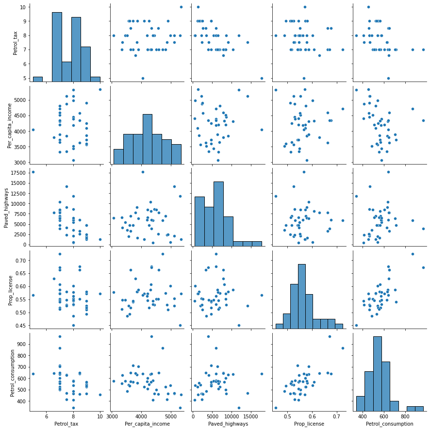

```python
petrol_pairplot = sns.pairplot(petrol_train)
```

#### Prop_license seems to be the variable that has the highest linear correlation with Petrol_consumption.

Fit a simple linear regression model to predict `Petrol_consumption` based on predictor *P* (identified in the previous part). Print the model summary.

*(4 points)*

```python
import statsmodels.formula.api as smf
simple_model = smf.ols(formula='Petrol_consumption ~ Prop_license', data=petrol_train).fit()
print(simple_model.summary())
```

```
                            OLS Regression Results
==============================================================================
Dep. Variable:     Petrol_consumption   R-squared:                       0.516
Model:                            OLS   Adj. R-squared:                  0.503
Method:                 Least Squares   F-statistic:                     40.51
Date:                Thu, 19 Jan 2023   Prob (F-statistic):           1.80e-07
Time:                        21:33:40   Log-Likelihood:                -231.59
No. Observations:                  40   AIC:                             467.2
Df Residuals:                      38   BIC:                             470.5
Df Model:                           1
Covariance Type:            nonrobust
================================================================================
                   coef    std err          t      P>|t|      [0.025      0.975]
--------------------------------------------------------------------------------
Intercept     -267.6155    132.038     -2.027      0.050    -534.912      -0.319
Prop_license  1479.1803    232.414      6.364      0.000    1008.682    1949.678
==============================================================================
Omnibus:                        5.963   Durbin-Watson:                   1.280
Prob(Omnibus):                  0.051   Jarque-Bera (JB):                4.620
Skew:                           0.762   Prob(JB):                       0.0993
Kurtosis:                       3.670   Cond. No.                         23.9
==============================================================================

Notes:
[1] Standard Errors assume that the covariance matrix of the errors is correctly specified.
```

Interpret the coefficient of `Prop_license`. What is the increase in petrol consumption for an increase of 0.05 in *P*?

*(2+2 points)*

#### This value is the estimated slope of the linear regression line. For every one unit change in Prop_license, the change in Petrol_license (the predicted variable) is 1479.1803 units

```python
petrol_increase = 0.05 * 1479.1803
print('For an increase of 0.05 in Prop_license, the increase in petrol consumption is:',petrol_increase, 'million gallons.')
```

```
For an increase of 0.05 in Prop_license, the increase in petrol consumption is: 73.95901500000001 million gallons.
```

Does petrol consumption have a statistically significant relationship with the predictor *P*? Justify your answer.

*(4 points)*

#### Yes. The p-value of the Prop_license variable is less than 0.05. There is strong evidence that the coefficient of Prop_license is different from zero so this relationship is statistically significant.

What is the R-squared? Interpret its value.

*(4 points)*

#### The R-squared value is 0.516. This means that 51.6% of the variance in Petrol_consumption can be explained by Prop_license in the model. With the value being 0.516, this a moderate fit of the model to the data.

Use the model developed above to estimate the petrol consumption for a state in which 50% of the population has a driver’s license. What are the confidence and prediction intervals for your estimate? Which interval includes the irreducible error?

*(4+3+3+2 = 12 points)*

```python
model_df = pd.DataFrame({'Prop_license':[0.5]})
prediction_value = simple_model.predict(model_df)
prediction = simple_model.get_prediction(model_df)
print(prediction_value)
```

```
0    471.974627
dtype: float64
```

#### Based on the model, if 50% of the population in a state has a driver’s license, the petrol consumption in that state is close to 472 million gallons.

```python
pred_summary = prediction.summary_frame(alpha=0.05)
conf_interval = pred_summary[['mean_ci_lower','mean_ci_upper']]
pred_interval = pred_summary[['obs_ci_lower', 'obs_ci_upper']]
print(conf_interval)
print(pred_interval)
```

```
   mean_ci_lower  mean_ci_upper
0       431.6968     512.252454
   obs_ci_lower  obs_ci_upper
0    302.822725    641.126528
```

#### The confidence interval is [[431.6968, 512.252454]] and the prediction interval is [[302.822725, 641.126528]]. The prediction interval includes the irreducible error and thus it is wider.

Use the model developed above to estimate the petrol consumption for a state in which 10% of the population has a driver’s license. Are you getting a reasonable estimate? Why or why not?

*(5 points)*

```python
model_df = pd.DataFrame({'Prop_license':[0.1]})
prediction = simple_model.predict(model_df)
print(prediction)
```

```
0   -119.697506
dtype: float64
```

#### The predicted consumption of petrol for a state with 10% of the population having a driver’s license is -119.697506 million gallons. This is not a reasonable prediction. In no way can a state, even with 0% of the population having a driver’s license, consume a negative amount petrol. I think this model can still possibly be viable as there is no real-life circumstance where only 10% of a state’s population would have a driver’s license.

What is the residual standard error of the model?

*(4 points)*

```python
import numpy as np
rse = np.sqrt(simple_model.mse_resid)
print('The residual standard error of this model is',rse)
```

```
The residual standard error of this model is 81.15342760294635
```

Using the model developed above, predict the petrol consumption for the observations in *petrol_consumption_test.csv*. Find the RMSE (Root mean squared error). Include the units of RMSE in your answer.

*(5 points)*

```python
petrol_test = pd.read_csv('petrol_consumption_test.csv')
```

```python
predictions = simple_model.predict(petrol_test)
print(predictions)
```

```
0    658.351349
1    565.162988
2    624.330201
3    483.808069
4    726.393644
5    576.996430
6    653.913808
7    609.538398
dtype: float64
```

```python
rmse = np.sqrt(((petrol_test['Petrol_consumption'] - predictions)**2).mean())
print('The RMSE of this model is',rmse,'million gallons of Petrol')
```

```
The RMSE of this model is 80.13903941152401 million gallons of Petrol
```

Based on the answers to the previous two questions, do you think the model is overfitting? Justify your answer.

*(4 points)*

#### I do not. The RSE on the training data is close to the RMSE on the test data. This shows that the performance of the model on unknown data is comparable to its performance on known data.

Make a scatterplot of `Petrol_consumption` vs `Prop_license` using *petrol_consumption_test.csv*. Over the scatterplot, plot the regression line, the prediction interval, and the confidence interval. Distinguish the regression line, prediction interval lines, and confidence interval lines with the following colors. Include the legend as well.

- Regression line: red
- Confidence interval lines: blue
- Prediction interval lines: green

*(4 points)*

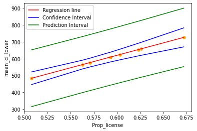

```python
import matplotlib.pyplot as plt
import seaborn as sns
intervals = simple_model.get_prediction(petrol_test)
interval_table = intervals.summary_frame(alpha=0.05)
predictions = intervals.predicted_mean
sns.scatterplot(x = petrol_test['Prop_license'], y = predictions, s = 50, color = 'orange')
sns.lineplot(x = petrol_test['Prop_license'], y = predictions, color = 'red', label='Regression line')
sns.lineplot(x = petrol_test['Prop_license'], y = interval_table['mean_ci_lower'], color='blue', label='Confidence Interval')
sns.lineplot(x = petrol_test['Prop_license'], y = interval_table['mean_ci_upper'], color='blue')
sns.lineplot(x = petrol_test['Prop_license'], y = interval_table['obs_ci_lower'], color = 'green', label='Prediction Interval')
sns.lineplot(x = petrol_test['Prop_license'], y = interval_table['obs_ci_upper'], color = 'green')
plt.legend()
plt.show()
```

Among the confidence and prediction intervals, which interval is wider, and why?

*(1+2 points)*

#### The prediciton interval is wider because it takes into account the uncertainty in the error which is unknown (aka the irreducible error).

Find the correlation between `Petrol_consumption` and the rest of the variables in *petrol_consumption_train.csv*. Based on the correlations, a simple linear regression model with which predictor will have the least R-squared value for predicting `Petrol_consumption`. Don’t develop any linear regression models.

*(4 points)*

```python
corr_matrix = petrol_train.corr()
corr_matrix.iloc[4:,]
```

|  | Petrol_tax | Per_capita_income | Paved_highways | Prop_license | Petrol_consumption |
| --- | --- | --- | --- | --- | --- |
| Petrol_consumption | -0.393415 | -0.314039 | 0.098117 | 0.718303 | 1.0 |

#### Based on the correlations between Petrol_consumption and the rest of the variables in the training dataset, the linear regression model with the Paved_highways variable as the predictor will have the least R-squared value for predicting Petrol_consumption. The R-squared value represents the square of the correlation coefficient, and since Paved_highways has the lowest absolute value correlation with Petrol_consumption, it will probably also have the least R-sqaured value.

**Bonus point question**

*(5 points - no partial credit)*

Fit a simple linear regression model to predict `Petrol_consumption` based on predictor *P*, but without an intercept term.

*(you must answer this correctly to qualify for earning bonus points)*

```python
bonus_model = smf.ols(formula='Petrol_consumption ~ Prop_license -1', data=petrol_train).fit()
```

Estimate the petrol consumption for the observations in *petrol_consumption_test.csv* using the model in developed in the previous question. Find the RMSE.

*(you must answer this correctly to qualify for earning bonus points)*

```python
predictions = bonus_model.predict(petrol_test)
print(predictions)
```

```
0    632.479344
1    568.827270
2    609.241285
3    513.257998
4    678.955462
5    576.910073
6    629.448293
7    599.137782
dtype: float64
```

```python
rmse = np.sqrt(((petrol_test['Petrol_consumption'] - predictions)**2).mean())
print('The RMSE of this model is',rmse)
```

```
The RMSE of this model is 76.398744492552
```

The RMSE for the models with and without the intercept are similar, which indicates that both models are almost equally good. However, the R-squared for the model without intercept is much higher than the R-squared for the model with the intercept. Why? Justify your answer.

*(5 points)*

#### When fitting a linear regression model without an intercept term, the model is forced to go through the origin. This means that if there is an intercept term, the model will adjust the slope to fit the data as best as possible. However, if the intercept term is not included, the slope of the line has to fit the data perfectly, otherwise, the model will not be able to produce a good fit. In this case, the R-squared value might be artificially high.

#### On the other hand, when fitting a linear regression model with an intercept term, the model will adjust the slope and the y-intercept to fit the data as best as possible. In this case, the R-squared value will be a more realistic measure of how well the model fits the data.